# Final Project

## Front Matter

```r
# clear enviornment
rm(list = ls())
# download packages
library(mdsr)
library(rvest)
library(readr)
library(tidyr)
library(rgeos)
library(rworldmap)
# read data
page <- "http://worldpopulationreview.com/countries/suicide-rate-by-country/"
xpath <- '//*[@id="__next"]/div/div[1]/div[2]/div[1]/div/div[2]/div/div/table'
table_list <-
  page %>%
  read_html() %>%
  html_nodes(xpath = xpath) %>%
  html_table(fill = TRUE)
Suicide <- table_list[[1]]
Happiness_Raw <- read.csv("2017_Happiness.csv")
Happy_Suicide <-
  Happiness_Raw %>%
  left_join(Suicide, by = c("Country" = "X1"))
map <- getMap(resolution = "low")
coordinates <- gCentroid(map, byid = TRUE)
Lat_Long <-
  coordinates %>%
  as.data.frame()
Lat_Long_Clean <-
  setNames(cbind(rownames(Lat_Long), Lat_Long, row.names = NULL),
         c("country", "latitude", "longitude"))
# user - defined functions
fitted_model <- function(a, data) {
  # fits a linear model based on provided estimates
  a[1] + data$GDP_per_capita * a[2]
}
resid_measurement <- function(mod, data) {
  # computes the root mean squared of a linear model based on provided estimates

  diff <- data$happiness_score - fitted_model(mod, data)
  sqrt(mean(diff ^ 2))
}
```

## Introduction

**To utilize our data science skills for social good we choose to investigate happiness levels across the world. Our first data set, The World Happiness Report (2017_Happiness.csv), scores each countries happiness using data from the Gallup World Poll. The data set was released at a UN event celebrating International Day of Happiness. The other variables included in the data set can be used as predictors for happiness. These predictors once understood could be used to influence public policy and assess countries progress. Our second data set provided the latitude and longitude of each country so that happiness could be evaluated on a regional basis as well as locally. The goal of our project was to determine what factors have the greatest influence on a countries happiness so that leaders can better target how to improve the well being of it’s citizens.**

## Project

```r
# clean data
Happiness <-
  Happiness_Raw %>%
  rename(country = Country,
         happiness_rank = Happiness.Rank,
         happiness_score = Happiness.Score,
         maximum_happiness = Whisker.high,
         minimum_happiness = Whisker.low,
         GDP_per_capita = Economy..GDP.per.Capita.,
         family = Family,
         life_expectancy = Health..Life.Expectancy.,
         freedom = Freedom,
         generosity = Generosity,
         corruption = Trust..Government.Corruption.)
Happiness
```

| country | happiness_rank | happiness_score | maximum_happiness | minimum_happiness | GDP_per_capita | family | life_expectancy | freedom | generosity | corruption | Dystopia.Residual |
| --- | --- | --- | --- | --- | --- | --- | --- | --- | --- | --- | --- |
| Norway | 1 | 7.537 | 7.594445 | 7.479556 | 1.61646318 | 1.5335236 | 0.796666503 | 0.63542259 | 0.36201224 | 0.315963835 | 2.2770267 |
| Denmark | 2 | 7.522 | 7.581728 | 7.462272 | 1.48238301 | 1.5511216 | 0.792565525 | 0.62600672 | 0.35528049 | 0.400770068 | 2.3137074 |
| Iceland | 3 | 7.504 | 7.622030 | 7.385970 | 1.48063302 | 1.6105740 | 0.833552122 | 0.62716264 | 0.47554022 | 0.153526559 | 2.3227153 |
| Switzerland | 4 | 7.494 | 7.561772 | 7.426227 | 1.56497955 | 1.5169117 | 0.858131289 | 0.62007058 | 0.29054928 | 0.367007285 | 2.2767162 |
| Finland | 5 | 7.469 | 7.527542 | 7.410458 | 1.44357193 | 1.5402467 | 0.809157670 | 0.61795086 | 0.24548277 | 0.382611543 | 2.4301815 |
| Netherlands | 6 | 7.377 | 7.427426 | 7.326574 | 1.50394464 | 1.4289392 | 0.810696125 | 0.58538449 | 0.47048983 | 0.282661825 | 2.2948041 |
| Canada | 7 | 7.316 | 7.384403 | 7.247597 | 1.47920442 | 1.4813490 | 0.834557652 | 0.61110091 | 0.43553972 | 0.287371516 | 2.1872644 |
| New Zealand | 8 | 7.314 | 7.379510 | 7.248490 | 1.40570605 | 1.5481951 | 0.816759706 | 0.61406213 | 0.50000513 | 0.382816702 | 2.0464563 |
| Sweden | 9 | 7.284 | 7.344095 | 7.223905 | 1.49438727 | 1.4781622 | 0.830875158 | 0.61292410 | 0.38539925 | 0.384398729 | 2.0975380 |
| Australia | 10 | 7.284 | 7.356651 | 7.211349 | 1.48441494 | 1.5100420 | 0.843886793 | 0.60160738 | 0.47769925 | 0.301183730 | 2.0652108 |

[output cut: 145 more lines]

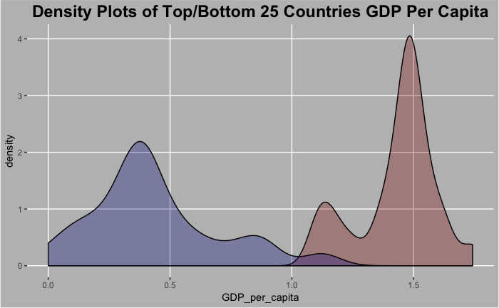

```r
# create density plots
Happiness_Top_25 <-
  Happiness %>%
  arrange(happiness_rank) %>%
  head(25)
Happiness_Bottom_25 <-
  Happiness %>%
  arrange(desc(happiness_rank)) %>%
  head(25)
Happiness_Top_25 %>%
  ggplot(aes(x = GDP_per_capita)) +
  geom_density(fill = "dark red", alpha = .3) +
  geom_density(aes(x = GDP_per_capita), data = Happiness_Bottom_25, fill = "dark blue", alpha = .3) +
  ggtitle("Density Plots of Top/Bottom 25 Countries GDP Per Capita") +
  theme(plot.background = element_rect(fill = 'grey'),
        plot.title = element_text(size = 17.5, lineheight = .8, vjust = 1, hjust = .5, family = "", face = "bold"),
        panel.background = element_rect(fill = 'grey'),
        panel.grid.major = element_line(color = "white"),
        panel.grid.minor = element_line(color = "grey"))
```

**The first thing we looked at was the density of GDP_per_capita for the top and bottom 25 happiest countries.**

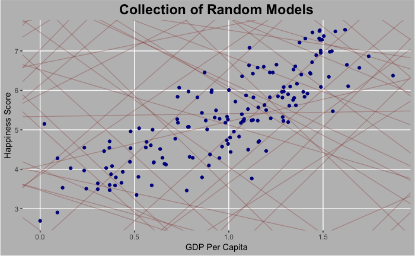

```r
Random_Models <-
  tibble(b0 = runif(250, -20, 40),
         b1 = runif(250, -5, 5))
Happiness %>%
  ggplot(aes(x = GDP_per_capita, y = happiness_score)) +
  geom_abline(aes(intercept = b0, slope = b1), data = Random_Models, alpha = 0.25, color = "dark red", size = .5) +
  geom_point(color = "dark blue") +
  xlab("GDP Per Capita") +
  ylab("Happiness Score") +
  ggtitle("Collection of Random Models") +
  theme(plot.background = element_rect(fill = 'grey'),
        plot.title = element_text(size = 17.5, lineheight = .8, vjust = 1, hjust = .5, family = "", face = "bold"),
        panel.background = element_rect(fill = 'grey'),
        panel.grid.major = element_line(color = "white"),
        panel.grid.minor = element_line(color = "grey"))
```

**We then began a search for the best intercept and slope for a model predicting happiness score for each country based on GDP per capita. We did this simply by generating a bunch of random lines that could serve as predictive models.**

```r
# find best coefficient estimates
Happy_Best <- optim(par = c(0, 0), fn = resid_measurement, data = Happiness)
Happy_Best$par
```

```
[1] 3.203957 2.183670
```

**We then found the optimal parameters for intercept and slope for a model predicting happiness score for each country based on GDP per capita, in order to have a more exact and less random approach to model fitting.**

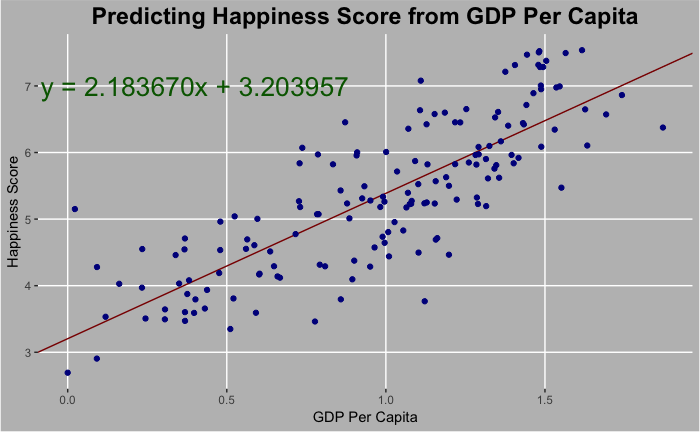

```r
# create optimal linear model
Happiness %>%
  ggplot(aes(x = GDP_per_capita, y = happiness_score)) +
  geom_abline(intercept = 3.203957, slope = 2.183670, color = "dark red",
              linetype = "solid", size = .5) +
  geom_point(color = "dark blue") +
  xlab("GDP Per Capita") +
  ylab("Happiness Score") +
  ggtitle("Predicting Happiness Score from GDP Per Capita") +
  annotate("text", x = .4, y = 7, label = "y = 2.183670x + 3.203957", size = 7, color = "dark green") +
  theme(plot.background = element_rect(fill = 'grey'),
        plot.title = element_text(size = 17.5, lineheight = .8, vjust = 1, hjust = .5, family = "", face = "bold"),
        panel.background = element_rect(fill = 'grey'),
        panel.grid.major = element_line(color = "white"),
        panel.grid.minor = element_line(color = "grey"))
```

**This graph showcases the plot of our best linear model for happiness score.**

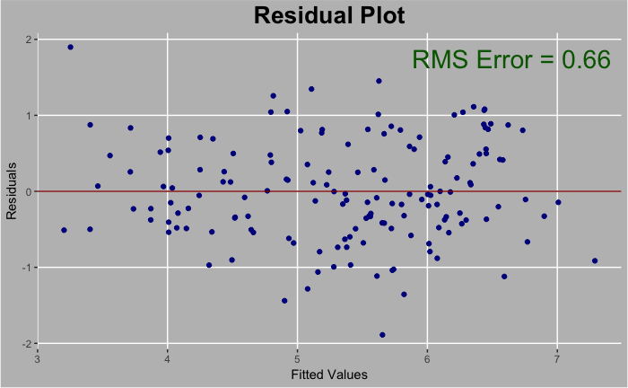

```r
# create optimal residual plot
mod_values <- 3.203957 + (2.183670 * Happiness$GDP_per_capita)
Happy_Dist <-
  Happiness %>%
  select(country, happiness_score) %>%
  mutate(model_values = mod_values,
         residuals = happiness_score - model_values)
Happy_Dist %>%
  ggplot(aes(x = model_values, y = residuals)) +
  geom_point(color = 'dark blue') +
  geom_hline(yintercept = 0, color = 'dark red') +
  xlab("Fitted Values") +
  ylab("Residuals") +
  ggtitle("Residual Plot") +
  annotate("text", x = 6.65, y = 1.75, label = "RMS Error = 0.66", size = 7.5, color = "dark green") +
  theme(plot.background = element_rect(fill = 'grey'),
        plot.title = element_text(size = 20, lineheight = .8, vjust = 1, hjust = .5, family = "", face = "bold"),
        panel.background = element_rect(fill = 'grey'),
        panel.grid.major = element_line(color = "white"),
        panel.grid.minor = element_line(color = "grey"))
```

**There is no distinct pattern among the model, so this residual plot shows that the linear model is a good fit for our data.**

```r
# calculate RMS error
sqrt(mean(Happy_Dist$residuals ^ 2))
```

```
[1] 0.6573817
```

```r
Happy_Min <-
  Happiness_Top_25 %>%
  select(country, minimum_happiness) %>%
  spread(key = country, value = minimum_happiness)
Happy_Max <-
  Happiness_Top_25 %>%
  select(country, maximum_happiness) %>%
  spread(key = country, value = maximum_happiness)
Happy_Mix_Max <-
  Happy_Min %>%
  rbind(Happy_Max)
apply(X = Happy_Mix_Max, FUN = mean, MARGIN = 2)
```

```
           Argentina            Australia              Austria              Belgium               Brazil               Canada
               6.599                7.284                7.006                6.891                6.635                7.316
               Chile           Costa Rica       Czech Republic              Denmark              Finland              Germany
               6.652                7.079                6.609                7.522                7.469                6.951
             Iceland              Ireland               Israel           Luxembourg               Mexico          Netherlands
               7.504                6.977                7.213                6.863                6.578                7.377
         New Zealand               Norway               Sweden          Switzerland United Arab Emirates       United Kingdom
               7.314                7.537                7.284                7.494                6.648                6.714
       United States
               6.993
```

**We looked at a measurement for the average happiness for the top 25 happiest countries, and began to notice that countries in the same region has similar levels of happiness. To further explore this, we decided to create a dendogram to examine the similarities between countries.**

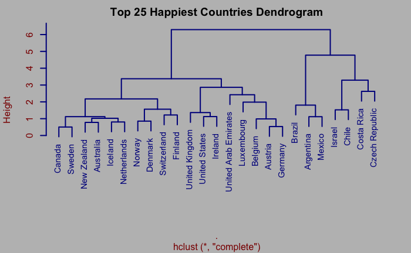

```r
# dendogram of top 25 happiest countries
Happiness_2 <- Happiness[-c(1)]
Happiness_2 <-
  Happiness_2 %>%
  select(happiness_rank, GDP_per_capita, life_expectancy, generosity, freedom) %>%
  arrange(happiness_rank) %>%
  head(25)

Happy_std <-
  scale(Happiness_2) %>%
  as.data.frame()
Happy_dist <-
  dist(Happy_std)
Happy_dendo <-
  Happy_dist %>%
  hclust(method = "complete")
labels <- Happiness_Top_25$country
par(bg = "grey")
Happy_dendo %>%
  plot(cex = 0.9, labels = labels, lwd = 2,
       main = "Top 25 Happiest Countries Dendrogram", col = "dark blue", col.axis = "dark red", col.lab = "dark red", col.sub = "dark red")
```

```r
# show happiness levels on a map
Happy_Places <-
  Happiness %>%
  left_join(Lat_Long_Clean) %>%
  select(country, latitude, longitude, happiness_score) %>%
  filter(latitude != "NA") %>%
  mutate(happiness_score = ifelse(happiness_score >= mean(happiness_score), "Top 50%", "Bottom 50%"))
```

```
Column `country` joining factors with different levels, coercing to character vector
```

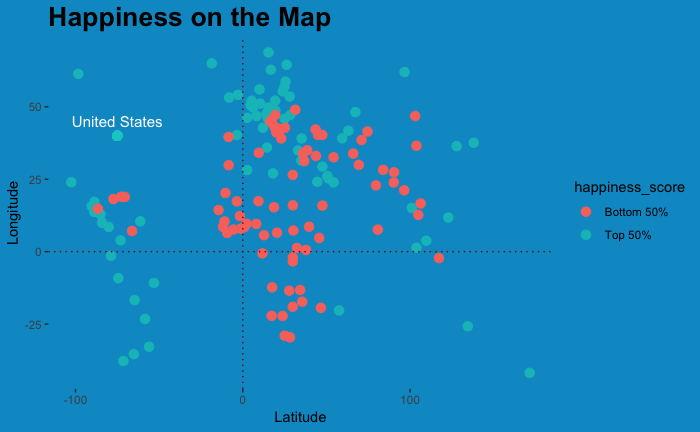

```r
Happy_Places %>%
  ggplot(aes(x = latitude, y = longitude)) +
  geom_point(aes(color = happiness_score), size = 3) +
  geom_point(aes(x = -75, y = 40), color = "cyan3", size = 3) +
  annotate("text", x = -75, y = 45, label = "United States", size = 4, color = "white")  +
  geom_hline(yintercept = 0, color = 'dark red', linetype = 'dotted') +
  geom_vline(xintercept = 0, color = 'dark red', linetype = "dotted") +
  xlab("Latitude") +
  ylab("Longitude") +
  ggtitle("Happiness on the Map") +
  theme(plot.background = element_rect(fill = 'deepskyblue3', color = "deepskyblue3"),
        plot.title = element_text(size = 20, lineheight = .8, vjust = 1, family = "", face = "bold"),
        panel.background = element_rect(fill = 'deepskyblue3'),
        panel.grid.major = element_line(color = "deepskyblue3"),
        panel.grid.minor = element_line(color = "deepskyblue3"),
        legend.background = element_rect(fill = "deepskyblue3"),
        legend.key = element_rect(fill = "deepskyblue3", color = NA))
```

**To show that the split of happiness was related to region we decided to graph the countries location along with happiness score.**